# Homework 1

**This homework is due on Jan. 25, 2021 at 11:00pm. Please submit as a pdf file on Canvas.**

**Problem 1: (4 pts)** Demonstrate basic command of Markdown by creating a bulleted list with three items, a numbered list with three items, and a sentence that has one word in bold and one word in italics.

Bulleted list:

- Item 1
- Item 2
- Item 3

Numbered list:

1. Item 1
2. Item 2
3. Item 3

This is a sentence with a word in **bold** and a word in *italics*.

**Problem 2: (3 pts)** The `economics` dataset contains various time series data from the US economy:

```r
economics
```

```
## # A tibble: 574 x 6
##    date         pce    pop psavert uempmed unemploy
##    <date>     <dbl>  <dbl>   <dbl>   <dbl>    <dbl>
##  1 1967-07-01  507. 198712    12.6     4.5     2944
##  2 1967-08-01  510. 198911    12.6     4.7     2945
##  3 1967-09-01  516. 199113    11.9     4.6     2958
##  4 1967-10-01  512. 199311    12.9     4.9     3143
##  5 1967-11-01  517. 199498    12.8     4.7     3066
##  6 1967-12-01  525. 199657    11.8     4.8     3018
##  7 1968-01-01  531. 199808    11.7     5.1     2878
##  8 1968-02-01  534. 199920    12.3     4.5     3001
##  9 1968-03-01  544. 200056    11.7     4.1     2877
## 10 1968-04-01  544  200208    12.3     4.6     2709
## # … with 564 more rows
```

Use ggplot to make a line plot of the number of unemployed (column `unemploy`) versus time (column `date`).

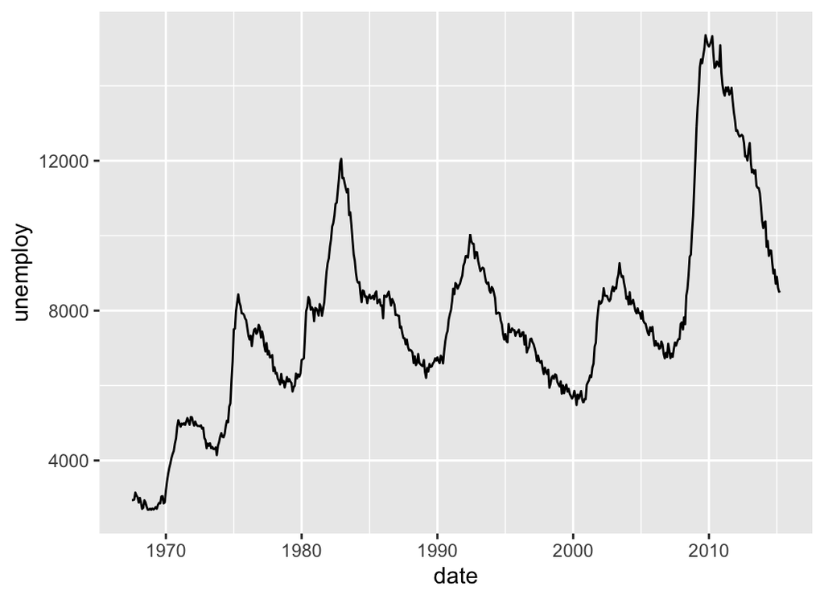

```r
ggplot(economics, aes(date, unemploy)) +
  geom_line()
```

**Problem 3: (3 pts)** Again using the `economics` dataset, now make a scatter plot (using `geom_point()`) of the number of unemployed versus the personal savings rate (`psavert`), and color points by date.

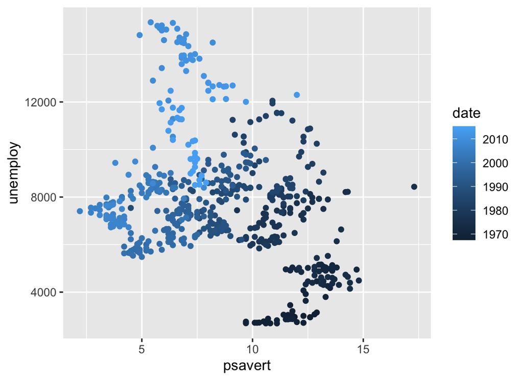

```r
ggplot(economics, aes(psavert, unemploy, color = date)) +
  geom_point()
```